# NFL Kicking

Jackson Monroe

5/23/2021

# Introduction

Being a kicker in the NFL involves kicking a football through upright goalposts that are eighteen and a half feet (6.17 yards) wide from distances ranging from 18 yards to 60+. Kickers are often evaluated by the proportion of attempted field goals they make, a reasonable metric that nevertheless ignores the variable distances that kicks are taken from, along with several other factors. This analysis will attempt to adjust for other factors that affect how difficult a kick is and from there estimate ratings for kickers who played from 2007 to 2020.

# Data

The data are from September of 2007 to September of 2020, and contain the game location/date, resulting score, whether a kick was blocked, who attempted the kick, what team they were on, what team they were facing, and most importantly the distance of the attempt.

# Make Percentage and Distance

The further away from the goalposts a kicker is the harder it is to make a field goal, pretty intuitive. This is true for two reasons, kicking further is harder, and as the goalposts grow farther their apparent width shrinks. It is difficult to disentangle the effect of these two as they are highly correlated.

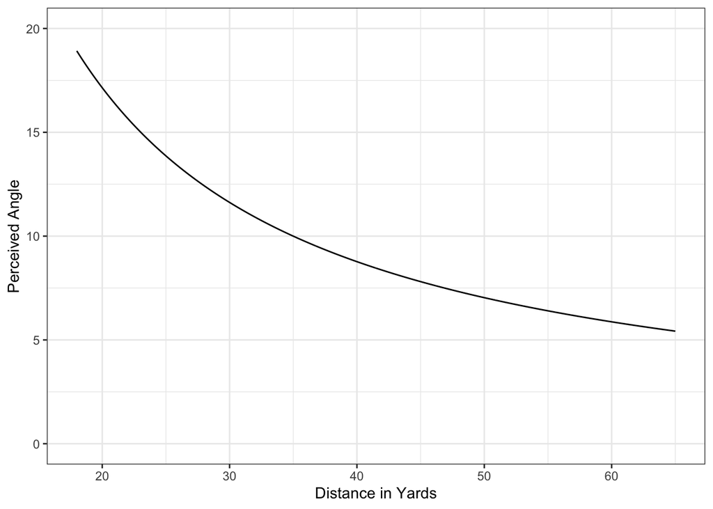

The data do not record whether missed kicks were short or to the left or right, but NFL fans will likely agree that long distance kicks usually miss due to falling short, and short to medium range kicks usually miss from kicking left or right of the goalposts. Future analyses will take the types of misses into account.

We see that the proportion of made kicks declines quadratically with distance, the chance of success declines faster and faster as the kicker gets further away. To model the relationship between distance and kick success we will use log-odds instead of proportions. Log-odds are defined as the logarithm of the probability of success divided by the probability of failure, which ranges the whole real numbers.[^1] Log-odds are very linear in distance, which is nice for a linear model as it is simple and well specified. When we create player ratings they will be in units of log-odds.

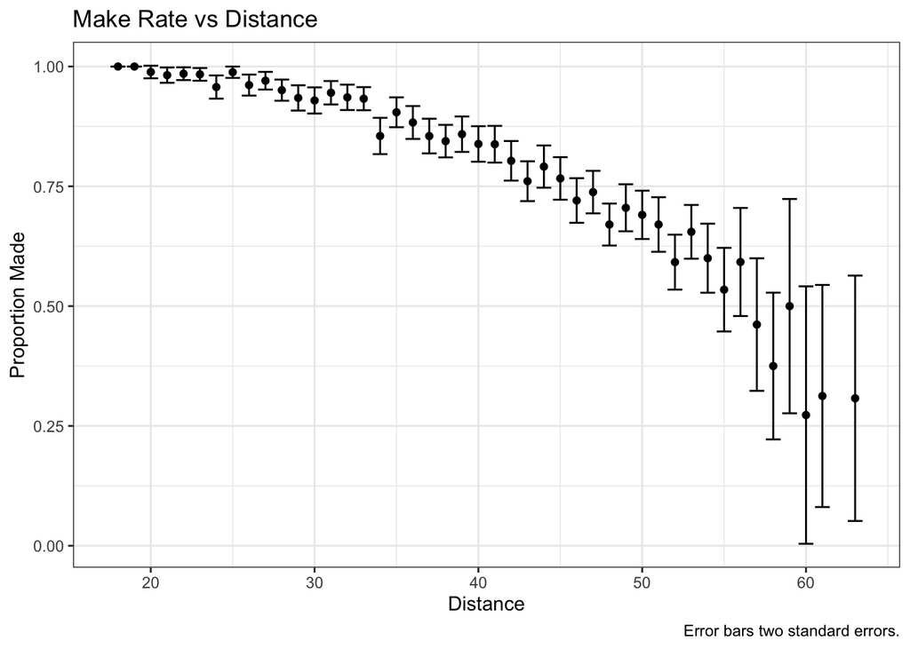

[figure not shown]

# Model

The model we specify is logistic, meaning it is linear in the log-odds of success. As we saw above, distance, the most important predictor, is linear in log-odds making this model a reasonable choice. The model is hierarchical, with kicks being analyzed with respect to each player. This allows us to assign a parameter value to each player that will indicate how being that player (i.e. having that player’s ability) changes the log-odds of successfully making a kick.

There is one other thing to note, the parameters (and the player ratings) are modeled as coming from a common distribution (this is known as a hierarchical model). This has the effect of shrinking every player’s rating to the mean (zero). Before everyone starts making Patrick Mahomes comments, it needs to be said that this is often a necessary and superior model choice from a statistical point of view. For example, in our data Johnny Hekker has attempted and made a single kick, a typical logistic regression without the hierarchical priors would try to make his rating go to infinity, because in log-odds terms his correct parameter is infinity.[^2] As thinking people we know that going one-for-one does not make you the best kicker in the world, we automatically look at 1/1 and say, “well that’s fine, but it’s so little information I basically have no idea how good of a kicker Johnny Hekker is.” A hierarchical model does this too, when players have few attempts it adjusts their rating towards the average, because with less data it makes sense to assume someone is about average. Players with many attempts will see their ratings moved very little toward the average.

$$\begin{align*}
log\Big(\frac{P(Make)}{1-P(Make)}\Big)&=\alpha_{Player}+\beta_{Distance}*Distance\\
\alpha_{Player}&\sim N(0, \sigma_{Player})\\
\beta_{Distance}&\sim N(0, \sigma_{Distance})
\end{align*}$$

This is most easily interpreted as a binomial model where the left-hand side is the log-odds of success. We have to use log-odds because when we transform the log-odds into a probability it will always be between zero and one, which is a requirement of the binomial distribution. This is the above equation rewritten after taking the inverse of the logit function.[^3]

$$kick_{dist} \sim Binomial(n_{dist}, logit^{-1}(\alpha_{Player}+\beta_{Distance}*Distance))$$
# Results

Player rating is roughly correlated with the career rate of success above 80%, but the relationship diminishes beneath 80%.

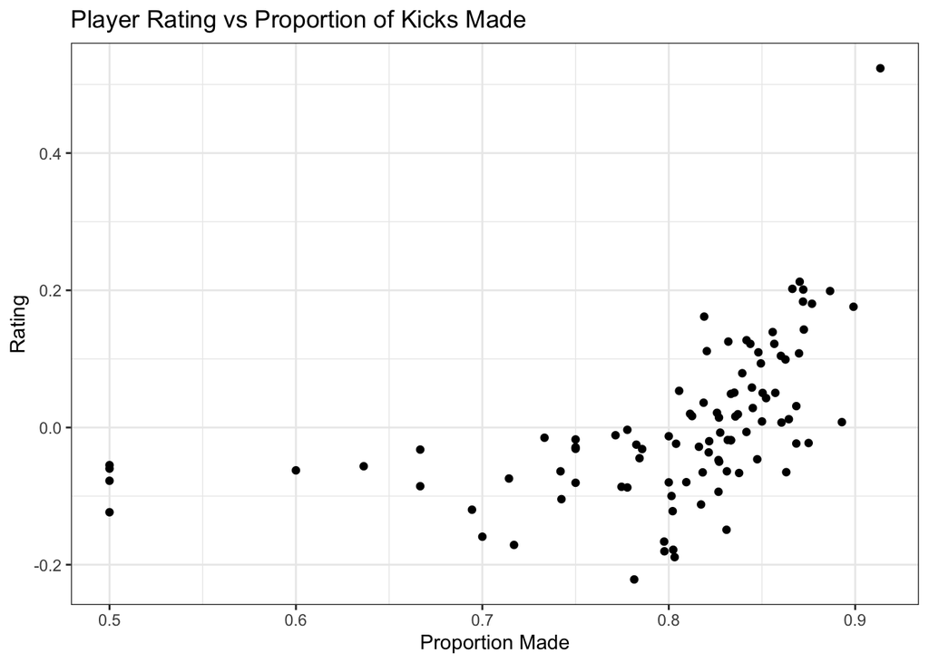

| Player | Rating | make_rate |
| --- | --- | --- |
| Justin Tucker | 0.524 | 0.913 |
| Dan Bailey | 0.213 | 0.870 |
| Matt Bryant | 0.202 | 0.866 |
| Rob Bironas | 0.201 | 0.872 |
| Josh Lambo | 0.199 | 0.887 |
| Robbie Gould | 0.184 | 0.872 |
| Wil Lutz | 0.180 | 0.877 |
| Harrison Butker | 0.176 | 0.899 |
| Sebastian Janikowski | 0.162 | 0.819 |
| Stephen Gostkowski | 0.143 | 0.872 |
| Kris Brown | -0.122 | 0.802 |
| Kyle Brindza | -0.123 | 0.500 |
| Lawrence Tynes | -0.149 | 0.831 |
| Roberto Aguayo | -0.159 | 0.700 |
| Nick Folk | -0.166 | 0.798 |
| Dave Rayner | -0.171 | 0.717 |
| David Akers | -0.178 | 0.802 |
| Mike Nugent | -0.180 | 0.798 |
| Olindo Mare | -0.189 | 0.803 |
| Billy Cundiff | -0.221 | 0.781 |

# Appendix

| Player | Rating | make_rate |
| --- | --- | --- |
| Justin Tucker | 0.524 | 0.913 |
| Dan Bailey | 0.213 | 0.870 |
| Matt Bryant | 0.202 | 0.866 |
| Rob Bironas | 0.201 | 0.872 |
| Josh Lambo | 0.199 | 0.887 |
| Robbie Gould | 0.184 | 0.872 |
| Wil Lutz | 0.180 | 0.877 |
| Harrison Butker | 0.176 | 0.899 |
| Sebastian Janikowski | 0.162 | 0.819 |
| Stephen Gostkowski | 0.143 | 0.872 |
| Stephen Hauschka | 0.139 | 0.856 |
| Jason Myers | 0.127 | 0.842 |
| Matt Prater | 0.125 | 0.832 |
| Josh Brown | 0.122 | 0.857 |
| Jason Hanson | 0.122 | 0.844 |
| Greg Zuerlein | 0.111 | 0.820 |
| Adam Vinatieri | 0.110 | 0.848 |
| Chris Boswell | 0.108 | 0.870 |
| Kai Forbath | 0.104 | 0.860 |
| Ryan Longwell | 0.099 | 0.863 |
| Phil Dawson | 0.093 | 0.849 |
| Dan Carpenter | 0.079 | 0.839 |
| Dustin Hopkins | 0.058 | 0.845 |
| Joey Slye | 0.053 | 0.806 |
| Jake Elliott | 0.051 | 0.835 |
| Joe Nedney | 0.050 | 0.857 |
| John Kasay | 0.050 | 0.850 |
| Ka’imi Fairbairn | 0.049 | 0.833 |
| Jay Feely | 0.043 | 0.852 |
| Blair Walsh | 0.036 | 0.819 |

[output cut: 69 more lines]

[^1]: 50% corresponds to 0 log-odds, 99% is 4.59.
[^2]: This is called “complete separation”.
[^3]: Taking the inverse of the logit function takes us from log-odds back to probabilities.